# R Notebook for australian beer production

Let us forecast quarterly australian beer production.

```r
library(ggplot2);library(ggthemes);library(gridExtra)  # For plots
library(quantmod);library(xts);library(zoo) # For using xts class objects
library(forecast) # Set of forecasting functions
library(fpp); library(fpp2) # Datasets from Forecasting text by Rob Hyndman
library(tseries) # for a statistical test
library(dplyr) # Data wrangling
```

## 0.1 Simple Forecasting Methods

```r
ausbeer
```

```
##      Qtr1 Qtr2 Qtr3 Qtr4
## 1956  284  213  227  308
## 1957  262  228  236  320
## 1958  272  233  237  313
## 1959  261  227  250  314
## 1960  286  227  260  311
## 1961  295  233  257  339
## 1962  279  250  270  346
## 1963  294  255  278  363
## 1964  313  273  300  370
## 1965  331  288  306  386
## 1966  335  288  308  402
## 1967  353  316  325  405
## 1968  393  319  327  442
## 1969  383  332  361  446
```

[output cut: 41 more lines]

Split the data into train and test. Since the test data contains 42 quarters, we will be constructing forecasts for 42 periods.

```r
train = window(ausbeer,end=c(1999,04))
test = window(ausbeer, start=c(2000,01))
length(test)
```

```
## [1] 42
```

### 0.1.1 Naive Method

Future will be the same as the last observation Since this is the best prediction for a random walk, these are also called random walk forecasts

#### 0.1.1.1 Model and Forecast

```r
naive_model = naive(train,h=42)
```

#### 0.1.1.2 Accuracy

```r
accuracy(naive_model,x=ausbeer)
```

```
##                      ME      RMSE      MAE        MPE     MAPE     MASE
## Training set   1.354286  70.30818 58.73714  -0.967862 13.94342 3.677753
## Test set     -93.309524 100.40881 93.30952 -22.690269 22.69027 5.842460
##                     ACF1 Theil's U
## Training set -0.22478344        NA
## Test set     -0.05298108  1.898409
```

### 0.1.2 Average Method

A very simple prediction, often the baseline in linear regression, is to use the average.

#### 0.1.2.1 Model and Forecast

```r
average_model = meanf(train,h = 42)
average_model
```

```
##         Point Forecast    Lo 80    Hi 80    Lo 95    Hi 95
## 2000 Q1       412.4318 291.6172 533.2464 227.0775 597.7861
## 2000 Q2       412.4318 291.6172 533.2464 227.0775 597.7861
## 2000 Q3       412.4318 291.6172 533.2464 227.0775 597.7861
## 2000 Q4       412.4318 291.6172 533.2464 227.0775 597.7861
## 2001 Q1       412.4318 291.6172 533.2464 227.0775 597.7861
## 2001 Q2       412.4318 291.6172 533.2464 227.0775 597.7861
## 2001 Q3       412.4318 291.6172 533.2464 227.0775 597.7861
## 2001 Q4       412.4318 291.6172 533.2464 227.0775 597.7861
## 2002 Q1       412.4318 291.6172 533.2464 227.0775 597.7861
## 2002 Q2       412.4318 291.6172 533.2464 227.0775 597.7861
## 2002 Q3       412.4318 291.6172 533.2464 227.0775 597.7861
## 2002 Q4       412.4318 291.6172 533.2464 227.0775 597.7861
## 2003 Q1       412.4318 291.6172 533.2464 227.0775 597.7861
## 2003 Q2       412.4318 291.6172 533.2464 227.0775 597.7861
```

[output cut: 28 more lines]

#### 0.1.2.2 Accuracy

Let us examine the accuracy of the above prediction from average_model on the train sample. accuracy() from library(forecast) is a handy function that automatically computes a set of error indices.

```r
accuracy(average_model)
```

```
##                         ME     RMSE      MAE       MPE     MAPE     MASE
## Training set -5.118499e-15 93.38414 74.56612 -6.210103 20.74216 4.668865
##                   ACF1
## Training set 0.7089738
```

Let us examine the accuracy on the test sample. To get test-set performance, set the x argument as the entire dataset rather than just the test set.

```r
accuracy(average_model,x = ausbeer)
```

```
##                         ME     RMSE      MAE       MPE      MAPE     MASE
## Training set -5.118499e-15 93.38414 74.56612 -6.210103 20.742160 4.668865
## Test set      1.525866e+01 40.10097 28.70346  2.876448  6.348359 1.797232
##                     ACF1 Theil's U
## Training set  0.70897377        NA
## Test set     -0.05298108 0.7832398
```

#### 0.1.2.3 Visualize Forecast

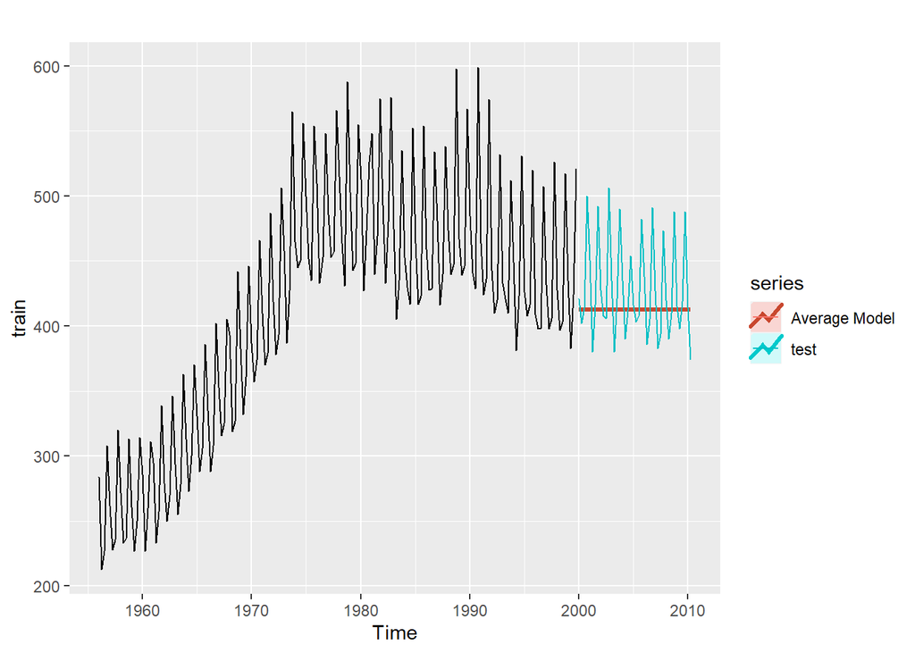

```r
autoplot(train)+
  autolayer(average_model,PI = F,size=1.1,series = 'Average Model')+
  autolayer(test)
```

### 0.1.3 Seasonal Naive Method

#### 0.1.3.1 Model and Forecast

```r
seasonal_naive_model = snaive(train,h=42)
seasonal_naive_model
```

```
##         Point Forecast    Lo 80    Hi 80    Lo 95    Hi 95
## 2000 Q1            435 409.3535 460.6465 395.7771 474.2229
## 2000 Q2            383 357.3535 408.6465 343.7771 422.2229
## 2000 Q3            424 398.3535 449.6465 384.7771 463.2229
## 2000 Q4            521 495.3535 546.6465 481.7771 560.2229
## 2001 Q1            435 398.7304 471.2696 379.5304 490.4696
## 2001 Q2            383 346.7304 419.2696 327.5304 438.4696
## 2001 Q3            424 387.7304 460.2696 368.5304 479.4696
## 2001 Q4            521 484.7304 557.2696 465.5304 576.4696
## 2002 Q1            435 390.5790 479.4210 367.0639 502.9361
## 2002 Q2            383 338.5790 427.4210 315.0639 450.9361
## 2002 Q3            424 379.5790 468.4210 356.0639 491.9361
## 2002 Q4            521 476.5790 565.4210 453.0639 588.9361
## 2003 Q1            435 383.7070 486.2930 356.5542 513.4458
## 2003 Q2            383 331.7070 434.2930 304.5542 461.4458
```

[output cut: 28 more lines]

#### 0.1.3.2 Accuracy

```r
accuracy(seasonal_naive_model,x = ausbeer)
```

```
##                     ME     RMSE      MAE       MPE     MAPE     MASE       ACF1
## Training set   4.25000 20.01206 15.97093  1.148642 3.818071 1.000000 0.02734555
## Test set     -11.54762 21.85286 17.02381 -2.521773 3.863916 1.065925 0.02909800
##              Theil's U
## Training set        NA
## Test set     0.4278746
```

#### 0.1.3.3 Visualize Forecast

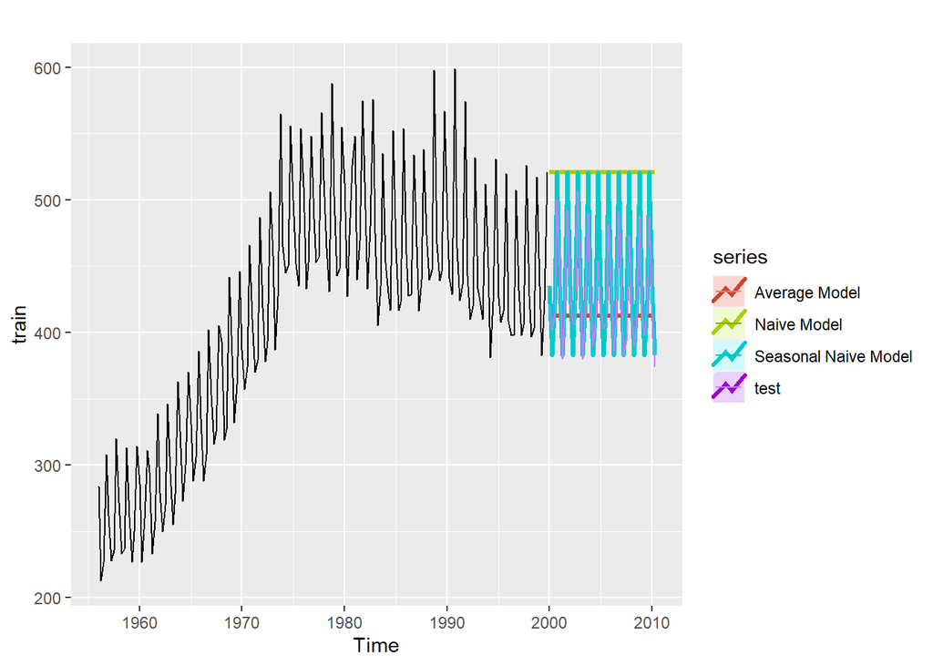

```r
autoplot(train)+
  autolayer(average_model,PI = F,size=1.1,series = 'Average Model')+
  autolayer(naive_model,PI=F,size=1.1, series='Naive Model')+
  autolayer(seasonal_naive_model,PI=F,size=1.1,series='Seasonal Naive Model')+
  autolayer(test)
```

### 0.1.4 Drift Method

Allow forecasts to increase or decrease over time, where the amount of change over time (called the drift) is set to be average change seen in historical data

#### 0.1.4.1 Model and Forecast

```r
drift_model = rwf(train,h=42,drift = T)
drift_model$mean
```

```
##          Qtr1     Qtr2     Qtr3     Qtr4
## 2000 522.3543 523.7086 525.0629 526.4171
## 2001 527.7714 529.1257 530.4800 531.8343
## 2002 533.1886 534.5429 535.8971 537.2514
## 2003 538.6057 539.9600 541.3143 542.6686
## 2004 544.0229 545.3771 546.7314 548.0857
## 2005 549.4400 550.7943 552.1486 553.5029
## 2006 554.8571 556.2114 557.5657 558.9200
## 2007 560.2743 561.6286 562.9829 564.3371
## 2008 565.6914 567.0457 568.4000 569.7543
## 2009 571.1086 572.4629 573.8171 575.1714
## 2010 576.5257 577.8800
```

#### 0.1.4.2 Accuracy

```r
accuracy(drift_model,x = ausbeer)
```

```
##                         ME      RMSE       MAE        MPE     MAPE     MASE
## Training set -3.572936e-15  70.29513  58.81084  -1.315888 13.97802 3.682368
## Test set     -1.224267e+02 129.44954 122.42667 -29.581531 29.58153 7.665594
##                    ACF1 Theil's U
## Training set -0.2247834        NA
## Test set      0.1520385  2.458927
```

#### 0.1.4.3 Visualize Forecast

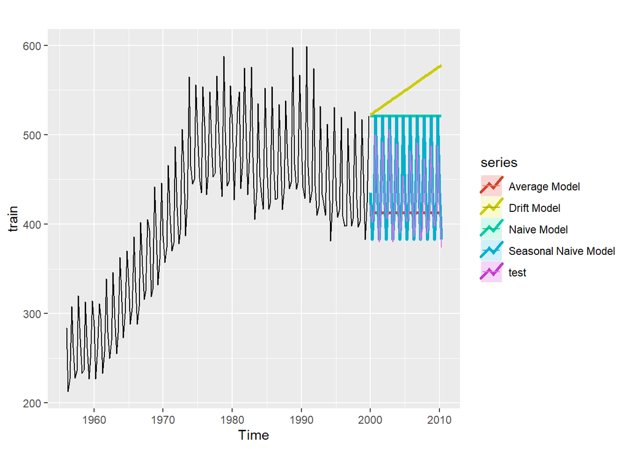

```r
autoplot(train)+
  autolayer(average_model,PI = F,size=1.1,series = 'Average Model')+
  autolayer(naive_model,PI=F,size=1.1, series='Naive Model')+
  autolayer(seasonal_naive_model,PI=F,size=1.1,series='Seasonal Naive Model')+
  autolayer(drift_model,PI=F,size=1.1,series='Drift Model')+
  autolayer(test)
```

## 0.2 Exponential Smoothing Models

Forecasts are weighted averages of past observations with the weights decaying exponentially such that recent observations get weighted more than distant observations.

### 0.2.1 Simple exponential smoothing

Forecasts are calculated using weighted averages, where the weights decrease exponentially. Most recent observations get the heaviest weight.

Simplest of exponential smoothing methods

Suitable for forecasting data with no clear trend or seasonal pattern.

#### 0.2.1.1 Model and Forecast

```r
ses_model = ses(train,h = 42)
ses_model$mean
```

```
##          Qtr1     Qtr2     Qtr3     Qtr4
## 2000 445.7878 445.7878 445.7878 445.7878
## 2001 445.7878 445.7878 445.7878 445.7878
## 2002 445.7878 445.7878 445.7878 445.7878
## 2003 445.7878 445.7878 445.7878 445.7878
## 2004 445.7878 445.7878 445.7878 445.7878
## 2005 445.7878 445.7878 445.7878 445.7878
## 2006 445.7878 445.7878 445.7878 445.7878
## 2007 445.7878 445.7878 445.7878 445.7878
## 2008 445.7878 445.7878 445.7878 445.7878
## 2009 445.7878 445.7878 445.7878 445.7878
## 2010 445.7878 445.7878
```

#### 0.2.1.2 Accuracy

```r
accuracy(ses_model,x = ausbeer)
```

```
##                     ME     RMSE      MAE        MPE     MAPE     MASE
## Training set   6.78376 52.86562 42.65547  0.5391999 10.07522 2.670819
## Test set     -18.09737 41.26471 37.68469 -4.9785614  8.97363 2.359580
##                     ACF1 Theil's U
## Training set -0.05109356        NA
## Test set     -0.05298108 0.7972014
```

#### 0.2.1.3 Visualize Forecasts

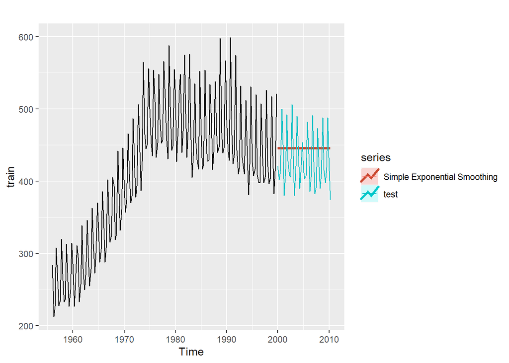

```r
autoplot(train)+
  autolayer(ses_model,series = "Simple Exponential Smoothing",PI = F, size=1.1)+
  autolayer(test)
```

### 0.2.2 Holt’s Method

Extends simple exponential smoothing to allow the forecasting of data with a trend

#### 0.2.2.1 Model and Forecast

```r
holt_model = holt(train,h=42)
holt_model$mean
```

```
##          Qtr1     Qtr2     Qtr3     Qtr4
## 2000 443.8257 448.1301 452.4345 456.7389
## 2001 461.0433 465.3477 469.6522 473.9566
## 2002 478.2610 482.5654 486.8698 491.1742
## 2003 495.4786 499.7830 504.0874 508.3918
## 2004 512.6962 517.0006 521.3051 525.6095
## 2005 529.9139 534.2183 538.5227 542.8271
## 2006 547.1315 551.4359 555.7403 560.0447
## 2007 564.3491 568.6535 572.9579 577.2624
## 2008 581.5668 585.8712 590.1756 594.4800
## 2009 598.7844 603.0888 607.3932 611.6976
## 2010 616.0020 620.3064
```

#### 0.2.2.2 Accuracy

```r
accuracy(holt_model,x=ausbeer)
```

```
##                       ME      RMSE       MAE         MPE      MAPE     MASE
## Training set    1.048297  51.06394  41.34716  -0.8878183  9.914797 2.588901
## Test set     -104.375595 124.04137 108.00085 -25.4057657 26.131936 6.762339
##                     ACF1 Theil's U
## Training set -0.03671365        NA
## Test set      0.61128212  2.375372
```

#### 0.2.2.3 Visualize Forecasts

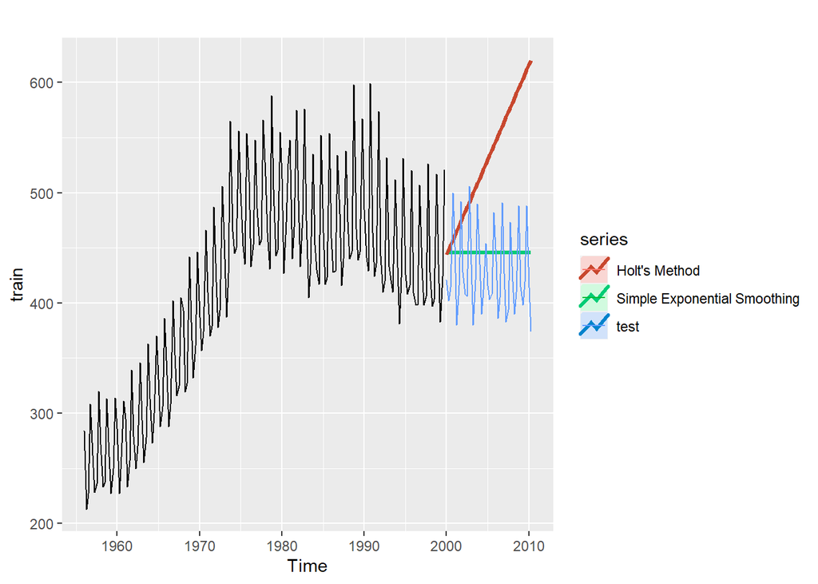

```r
autoplot(train)+
  autolayer(ses_model,series = "Simple Exponential Smoothing",PI = F, size=1.1)+
  autolayer(holt_model,series="Holt's Method",PI=F,size=1.1)+
  autolayer(test)
```

### 0.2.3 Holt’s Method with Damping

Forecasts generally display a constant trend (increasing or decreasing) indefinitely into the future. For this reason, a damping parameter is usually included

#### 0.2.3.1 Model and Forecast

```r
holt_damped_model = holt(train,h=42,damped = T)
holt_damped_model$mean
```

```
##          Qtr1     Qtr2     Qtr3     Qtr4
## 2000 441.6555 443.9208 445.9752 447.8384
## 2001 449.5282 451.0607 452.4506 453.7112
## 2002 454.8544 455.8912 456.8315 457.6844
## 2003 458.4578 459.1593 459.7954 460.3724
## 2004 460.8957 461.3702 461.8006 462.1910
## 2005 462.5450 462.8660 463.1572 463.4213
## 2006 463.6608 463.8780 464.0750 464.2537
## 2007 464.4157 464.5627 464.6960 464.8168
## 2008 464.9265 465.0259 465.1161 465.1978
## 2009 465.2720 465.3393 465.4003 465.4556
## 2010 465.5058 465.5513
```

#### 0.2.3.2 Accuracy

```r
accuracy(holt_damped_model,x=ausbeer)
```

```
##                      ME     RMSE      MAE        MPE      MAPE     MASE
## Training set   3.113352 50.01115 40.99473 -0.3297766  9.791311 2.566834
## Test set     -32.180549 49.84832 44.97675 -8.3039388 10.897279 2.816164
##                      ACF1 Theil's U
## Training set -0.059527825        NA
## Test set     -0.005103579 0.9593471
```

#### 0.2.3.3 Visualize Forecasts

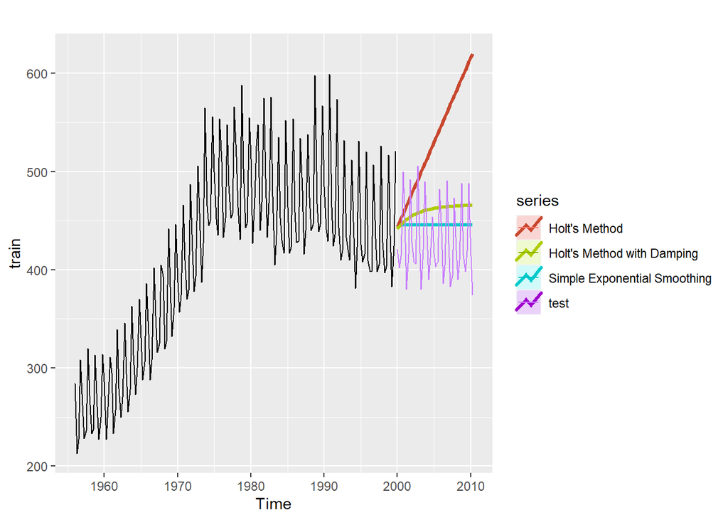

```r
autoplot(train)+
  autolayer(ses_model,series = "Simple Exponential Smoothing",PI = F, size=1.1)+
  autolayer(holt_model,series="Holt's Method",PI=F,size=1.1)+
  autolayer(holt_damped_model,series="Holt's Method with Damping",PI=F,size=1.1)+
  autolayer(test)
```

### 0.2.4 Holt-Winter’s seasonal method

Extends Holt’s method to capture seasonality. Two types: 1.Additive method is used when seasonal variations are roughly constant 2.Multiplicative method is used when seasonal variations change in proportion to the level of the series

### 0.2.5 Holt_Winter’s Additive

#### 0.2.5.1 Model and Forecast

```r
hw_additive = hw(train,h=42,seasonal = 'additive', damped=T)
hw_additive$mean
```

```
##          Qtr1     Qtr2     Qtr3     Qtr4
## 2000 431.7122 396.8446 412.7531 524.0245
## 2001 433.3171 398.1286 413.7803 524.8462
## 2002 433.9745 398.6545 414.2010 525.1828
## 2003 434.2438 398.8699 414.3733 525.3207
## 2004 434.3541 398.9581 414.4439 525.3771
## 2005 434.3992 398.9943 414.4728 525.4003
## 2006 434.4177 399.0091 414.4847 525.4097
## 2007 434.4253 399.0151 414.4895 525.4136
## 2008 434.4284 399.0176 414.4915 525.4152
## 2009 434.4297 399.0186 414.4923 525.4159
## 2010 434.4302 399.0190
```

#### 0.2.5.2 Accuracy

```r
accuracy(hw_additive,x = ausbeer)
```

```
##                      ME     RMSE      MAE        MPE     MAPE      MASE
## Training set   1.339248 16.02895 12.41005  0.2859756 3.005731 0.7770402
## Test set     -14.058340 22.67754 16.71429 -3.1512303 3.775641 1.0465444
##                    ACF1 Theil's U
## Training set -0.1816207        NA
## Test set     -0.1857105 0.4430322
```

#### 0.2.5.3 Visualize Forecasts

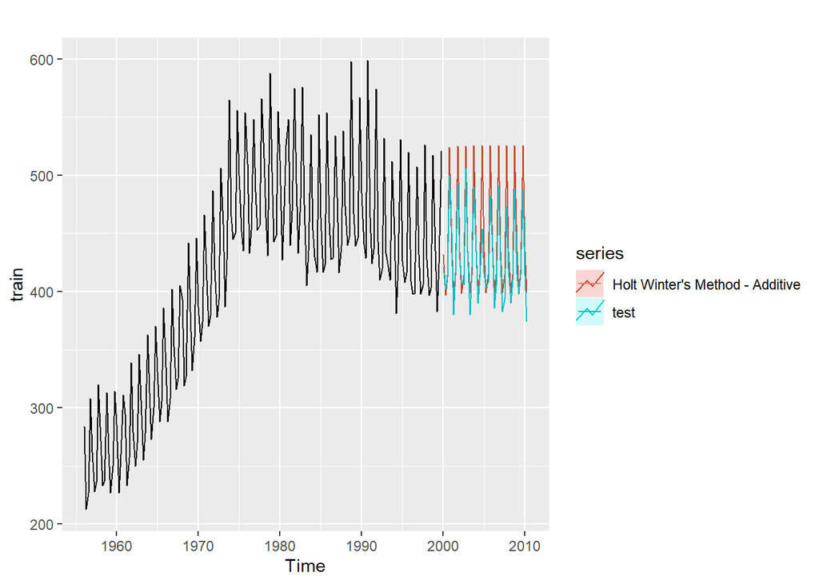

```r
autoplot(train)+
  autolayer(hw_additive,series="Holt Winter's Method - Additive",PI=F)+
  autolayer(test)
```

### 0.2.6 Holt_Winter’s Multiplicative

#### 0.2.6.1 Model and Forecast

```r
hw_multiplicative = hw(train,h=42,seasonal = 'multiplicative', damped=T)
hw_multiplicative$mean
```

```
##          Qtr1     Qtr2     Qtr3     Qtr4
## 2000 432.4894 398.2671 413.6034 524.9590
## 2001 435.1293 400.2185 415.2329 526.6252
## 2002 436.2614 401.0644 415.9487 527.3690
## 2003 436.7758 401.4576 416.2903 527.7351
## 2004 437.0374 401.6654 416.4787 527.9464
## 2005 437.1954 401.7973 416.6044 528.0945
## 2006 437.3110 401.8981 416.7043 528.2166
## 2007 437.4093 401.9861 416.7938 528.3281
## 2008 437.5005 402.0690 416.8789 528.4353
## 2009 437.5887 402.1497 416.9623 528.5407
## 2010 437.6758 402.2296
```

#### 0.2.6.2 Accuracy

```r
accuracy(hw_multiplicative,x=ausbeer)
```

```
##                      ME     RMSE      MAE       MPE     MAPE      MASE
## Training set   1.259767 15.55545 11.94622  0.314631 2.887841 0.7479979
## Test set     -16.474394 24.38794 18.20496 -3.721500 4.125710 1.1398809
##                    ACF1 Theil's U
## Training set -0.2232171        NA
## Test set     -0.1694875  0.475703
```

#### 0.2.6.3 Visualize Forecasts

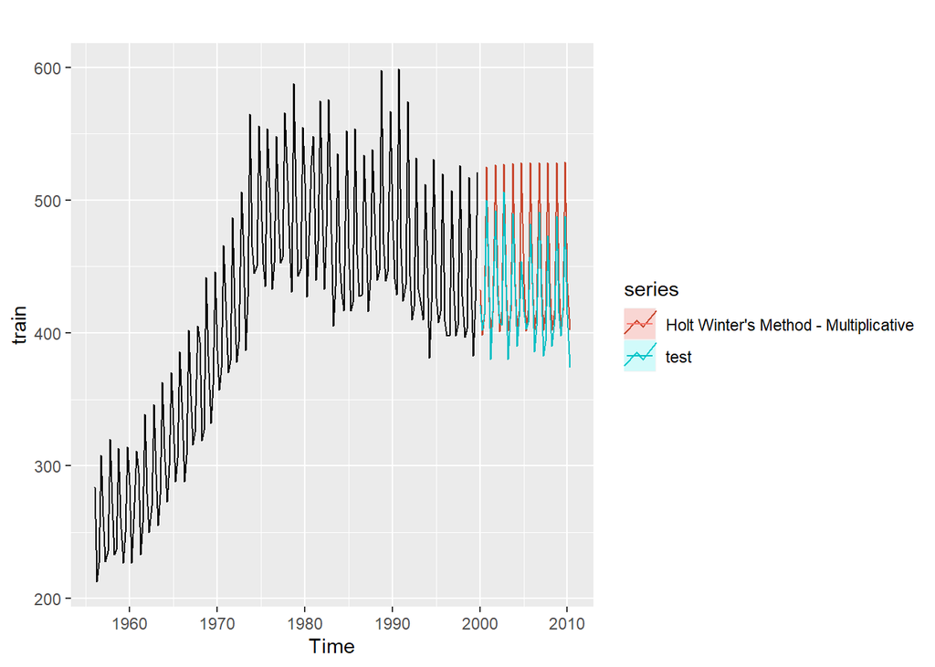

```r
autoplot(train)+
  autolayer(hw_multiplicative,series="Holt Winter's Method - Multiplicative",PI=F)+
  autolayer(test)
```

## 0.3 ETS Models

But, exponential smoothing methods are not limited to the ones examined so far. By considering variations of trend (none, additive, additive damped) and seasonal components (non, additive, multiplicative), there are nine exponential smoothing methods. And, for each of these methods, errors may be additive or multiplicative.

```r
ets_aaa = ets(train,model = 'AAA')
```

Summary of the model. Note, since we did not specify the damping term, ets() tried both an Additive-Damped trend and just an Additived trend and went with the option that led to a lower AICc.

```r
summary(ets_aaa)
```

```
## ETS(A,A,A)
##
## Call:
##  ets(y = train, model = "AAA")
##
##   Smoothing parameters:
##     alpha = 0.2284
##     beta  = 0.0375
##     gamma = 0.203
##
##   Initial states:
##     l = 259.2793
##     b = 0.2011
##     s = 52.7137 -20.0076 -41.6237 8.9176
##
##   sigma:  16.5039
##
##      AIC     AICc      BIC
## 1906.683 1907.768 1935.218
##
## Training set error measures:
##                     ME     RMSE      MAE         MPE     MAPE      MASE
## Training set 0.0339053 16.12443 12.43517 -0.02612254 2.989648 0.7786129
##                    ACF1
## Training set -0.2047428
```

Examine the residuals. Based on the ACF plot and a significant Ljung-Box test, residuals are not like white noise.

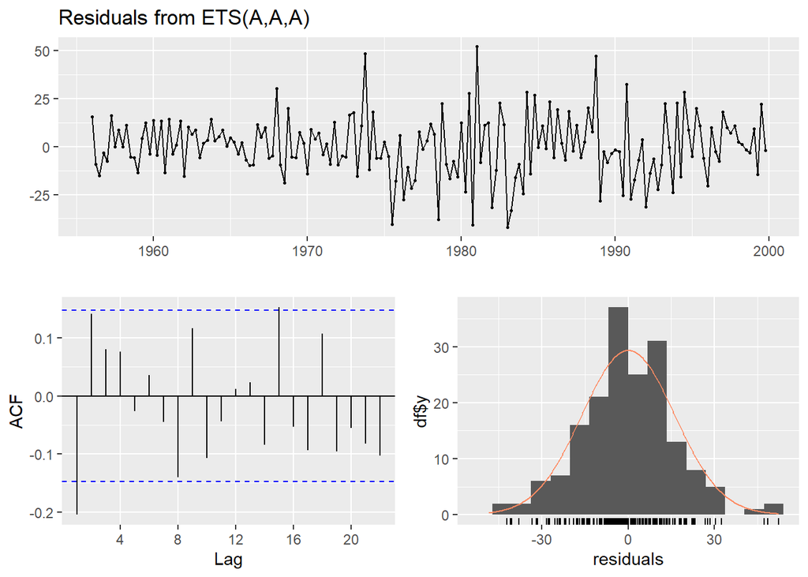

```
##
##  Ljung-Box test
##
## data:  Residuals from ETS(A,A,A)
## Q* = 17.733, df = 8, p-value = 0.02332
##
## Model df: 0.   Total lags used: 8
```

```r
checkresiduals(ets_aaa)
```

#### 0.3.0.1 Forecast

```r
ets_aaa_forecast = forecast(ets_aaa,h=42)
ets_aaa_forecast
```

```
##         Point Forecast    Lo 80    Hi 80    Lo 95    Hi 95
## 2000 Q1       431.7860 410.6354 452.9365 399.4390 464.1330
## 2000 Q2       396.8128 374.9274 418.6982 363.3419 430.2836
## 2000 Q3       412.7249 389.9184 435.5315 377.8453 447.6045
## 2000 Q4       523.7759 499.8572 547.6946 487.1954 560.3564
## 2001 Q1       433.4849 406.5913 460.3785 392.3547 474.6151
## 2001 Q2       398.5117 370.2168 426.8065 355.2385 441.7849
## 2001 Q3       414.4238 384.5491 444.2985 368.7344 460.1133
## 2001 Q4       525.4748 493.8485 557.1011 477.1066 573.8431
## 2002 Q1       435.1838 399.9788 470.3888 381.3424 489.0251
## 2002 Q2       400.2106 363.0282 437.3930 343.3450 457.0762
## 2002 Q3       416.1227 376.8129 455.4326 356.0035 476.2420
## 2002 Q4       527.1737 485.5943 568.7531 463.5835 590.7640
## 2003 Q1       436.8827 391.3182 482.4472 367.1978 506.5676
## 2003 Q2       401.9095 353.8973 449.9217 328.4811 475.3379
```

[output cut: 28 more lines]

#### 0.3.0.2 Accuracy

```r
accuracy(ets_aaa_forecast,x = ausbeer)
```

```
##                       ME     RMSE      MAE         MPE     MAPE      MASE
## Training set   0.0339053 16.12443 12.43517 -0.02612254 2.989648 0.7786129
## Test set     -20.3899116 28.22830 22.12902 -4.65481860 5.060769 1.3855813
##                     ACF1 Theil's U
## Training set -0.20474276        NA
## Test set      0.01545558 0.5492527
```

#### 0.3.0.3 Visualize Forecast

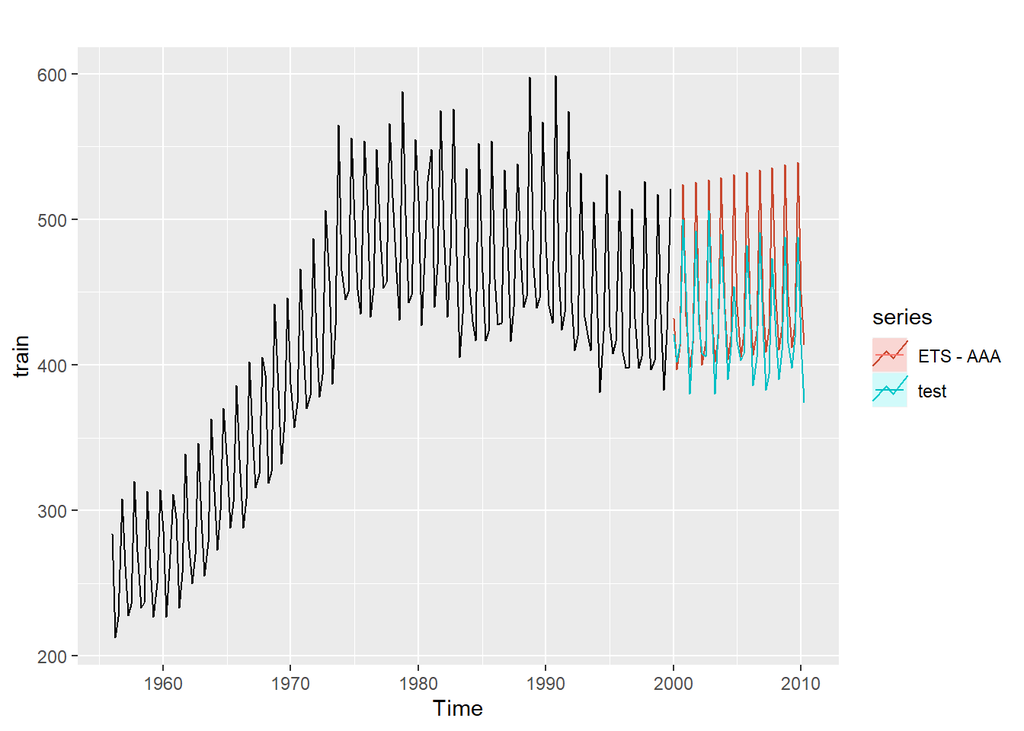

```r
autoplot(train)+
  autolayer(ets_aaa_forecast,series="ETS - AAA",PI=F)+
  autolayer(test)
```

### 0.3.1 ETS: Automatic Selection

When only the time-series is specified, and all other arguments are left at their default values, then ets() will automatically select the best model based on AICc. Compare the AICc for this model to ETS(A,A,A) above. Note that the chosen model has Multiplicative Errors, Additive Trend, and Multiplicative Seasonal.

#### 0.3.1.1 Model

```r
ets_auto = ets(train)
summary(ets_auto)
```

```
## ETS(M,A,M)
##
## Call:
##  ets(y = train)
##
##   Smoothing parameters:
##     alpha = 0.2263
##     beta  = 0.035
##     gamma = 0.1766
##
##   Initial states:
##     l = 255.5524
##     b = 0.8861
##     s = 1.1819 0.9125 0.8628 1.0428
##
##   sigma:  0.0371
##
##      AIC     AICc      BIC
## 1869.636 1870.720 1898.170
##
## Training set error measures:
##                      ME    RMSE      MAE         MPE    MAPE     MASE
## Training set -0.2090563 15.8621 12.12096 -0.04973312 2.91519 0.758939
##                    ACF1
## Training set -0.1999151
```

#### 0.3.1.2 Forecast

```r
ets_auto_forecast = forecast(ets_auto,h=42)
```

#### 0.3.1.3 Accuracy

```r
accuracy(ets_auto_forecast,x = ausbeer)
```

```
##                       ME     RMSE      MAE         MPE     MAPE     MASE
## Training set  -0.2090563 15.86210 12.12096 -0.04973312 2.915190 0.758939
## Test set     -20.4860097 28.61288 22.23155 -4.66935195 5.076505 1.392001
##                    ACF1 Theil's U
## Training set -0.1999151        NA
## Test set      0.0102163  0.556942
```

#### 0.3.1.4 Visualize Forecast

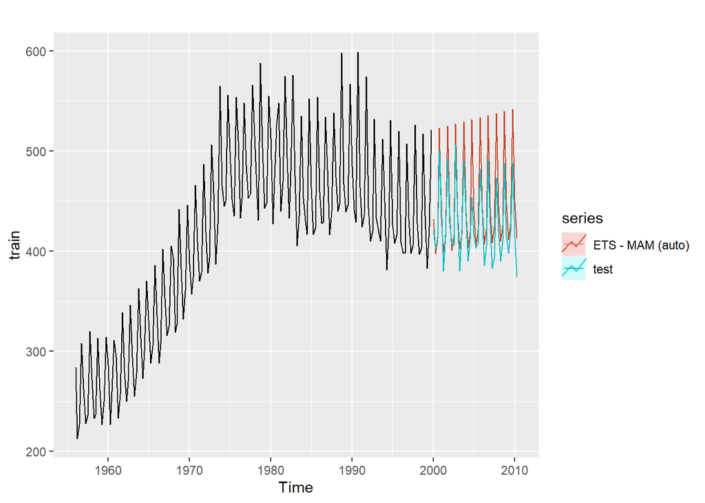

```r
autoplot(train)+
  autolayer(ets_auto_forecast,series="ETS - MAM (auto)",PI=F)+
  autolayer(test)
```

## 0.4 ARIMA

Exponential Smoothing and ARIMA are the two most widely used approaches to time-series forecasting and provide complementary approaches to the problem. While Exponential Smoothing models are based on a description of trend and seasonality in the data, ARIMA models aim to describe autocorrelations in the data

Since an ARMA process assumes the data is stationary, let us examine the assumption of stationarity and how to satisfy it.

Stationary Process has constant mean, variance and covariance (between identically spaced data points) over time. Stationarity is an assumption of many time-series analysis procedures. However, most time-series are non-stationary Fortunately, a non-stationary process can be transformed into a (weakly) stationary process through transformations that remove trend and stabilize variance. We will stabilize variance using a Box-Cox Transformation and remove seasonality and trend using differencing

### 0.4.1 ARIMA Model

Plot data to identify any unusual observations

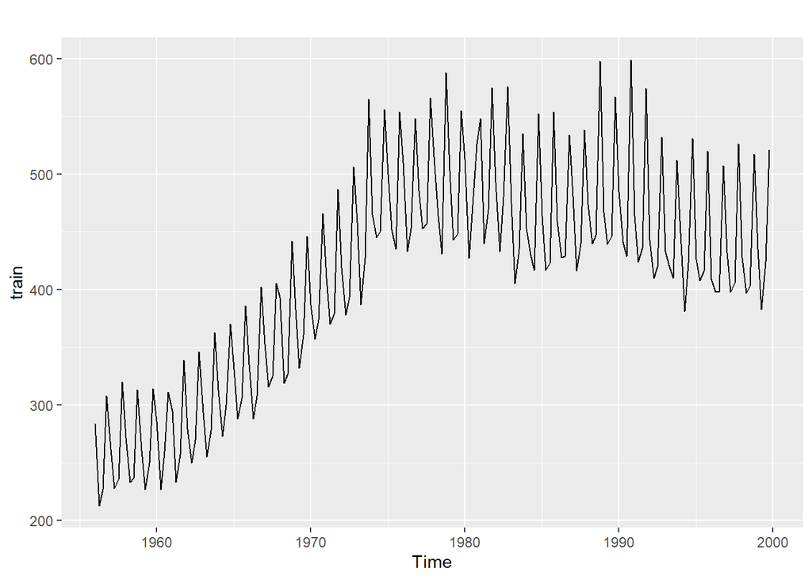

```r
autoplot(train)
```

Stabilize Variance

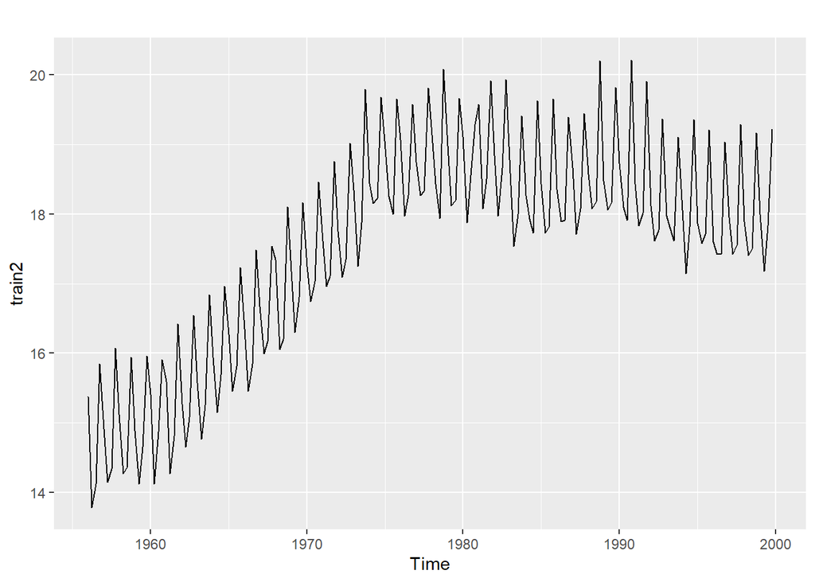

```r
train2 = BoxCox(train,lambda = BoxCox.lambda(train))
autoplot(train2)
```

The data are non-stationary, take first differences until the data are stationary

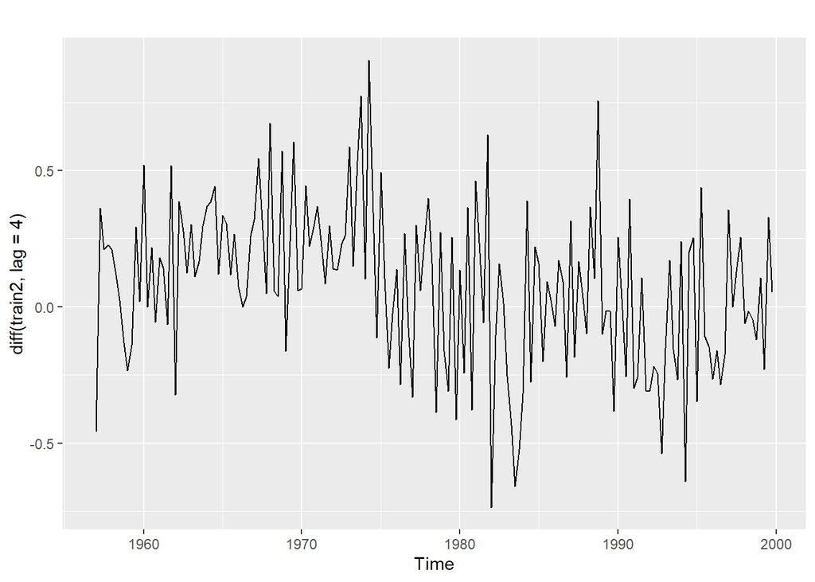

```r
autoplot(diff(train2,lag = 4))
```

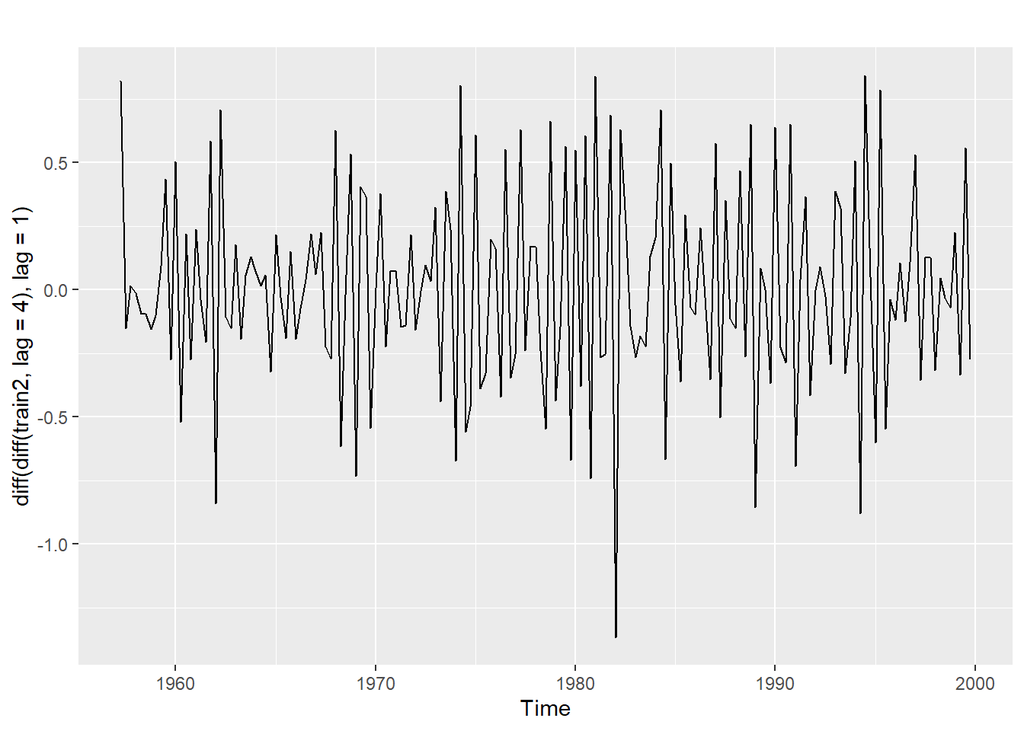

```r
autoplot(diff(diff(train2,lag = 4),lag=1))
```

Examine ACF and PACF to decide on AR (ARIMA(p,d,0) and/or MA terms (ARIMA(0,d,q))

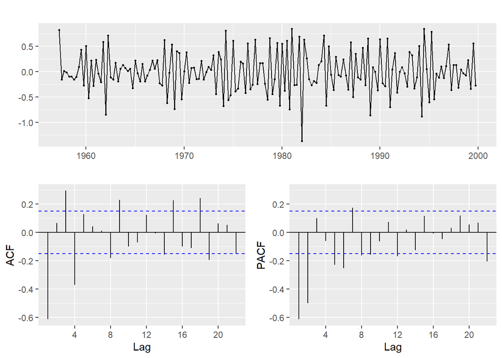

```r
train2 %>%
  diff(lag=4)%>%
  diff(lag=1)%>%
  ggtsdisplay()
```

Try chosen model and use AICc to search for a better model

```r
model1 = Arima(y = train,order = c(0,1,2),seasonal = c(0,1,1),lambda = BoxCox.lambda(train))
model1
```

```
## Series: train
## ARIMA(0,1,2)(0,1,1)[4]
## Box Cox transformation: lambda= 0.3102148
##
## Coefficients:
##           ma1     ma2     sma1
##       -0.9665  0.4085  -0.8268
## s.e.   0.0713  0.0729   0.0499
##
## sigma^2 = 0.05151:  log likelihood = 9.93
## AIC=-11.86   AICc=-11.62   BIC=0.71
```

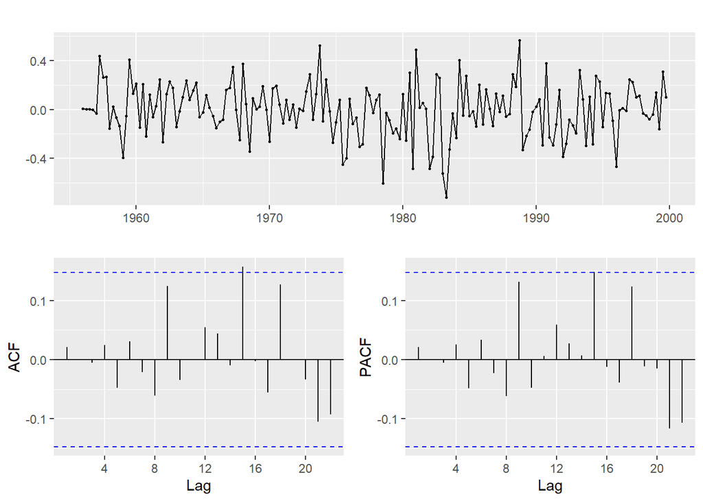

```r
ggtsdisplay(residuals(model1))
```

Trying out an alternative model

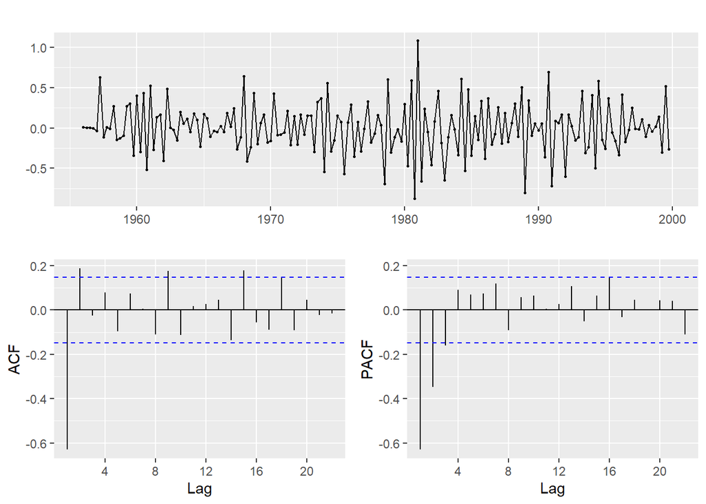

```r
model2 = Arima(y = train,order = c(0,1,0),seasonal = c(0,1,1),lambda = BoxCox.lambda(train))
ggtsdisplay(residuals(model2))
```

Check residuals by plotting. If they do not look like white noise, try a modified model

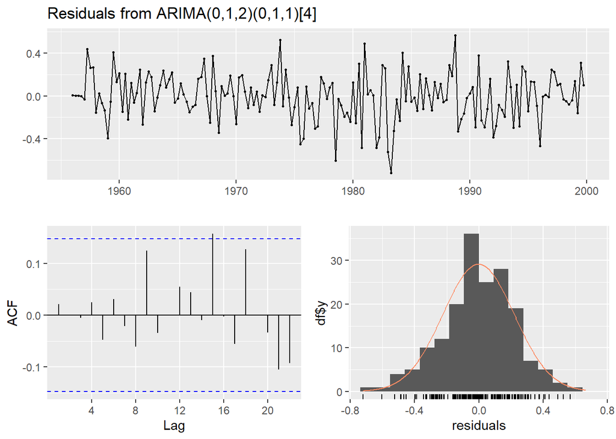

```
##
##  Ljung-Box test
##
## data:  Residuals from ARIMA(0,1,2)(0,1,1)[4]
## Q* = 1.5798, df = 5, p-value = 0.9037
##
## Model df: 3.   Total lags used: 8
```

```r
checkresiduals(model1)
```

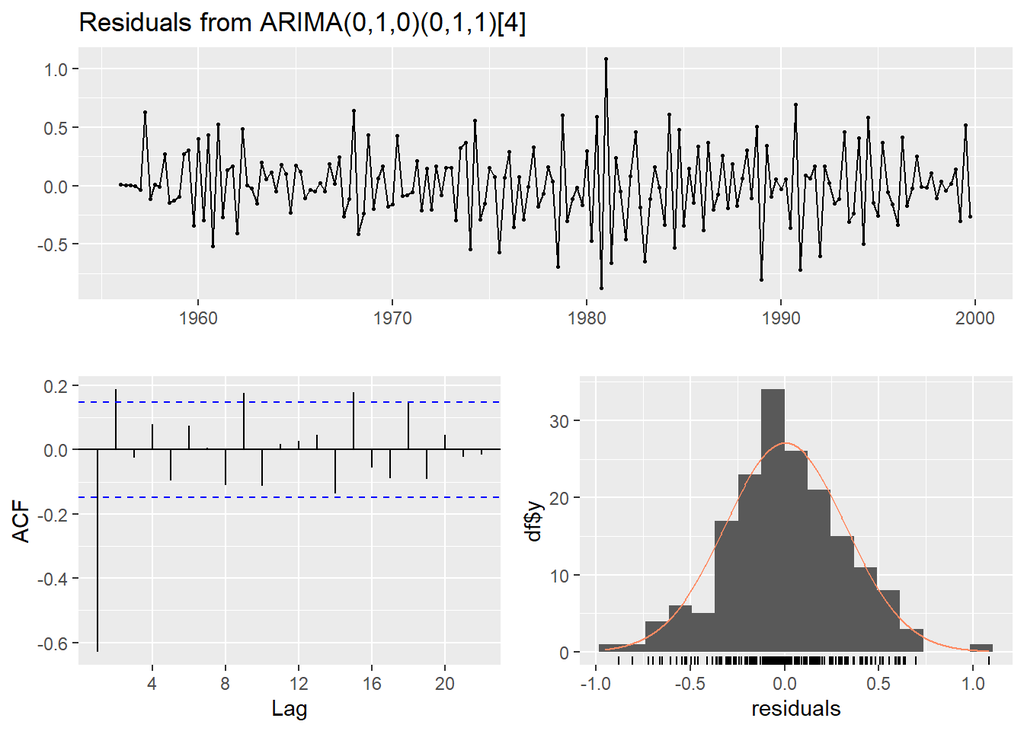

```
##
##  Ljung-Box test
##
## data:  Residuals from ARIMA(0,1,0)(0,1,1)[4]
## Q* = 83.58, df = 7, p-value = 2.554e-15
##
## Model df: 1.   Total lags used: 8
```

```r
checkresiduals(model2)
```

The residuals look like white noise, calculate forecasts

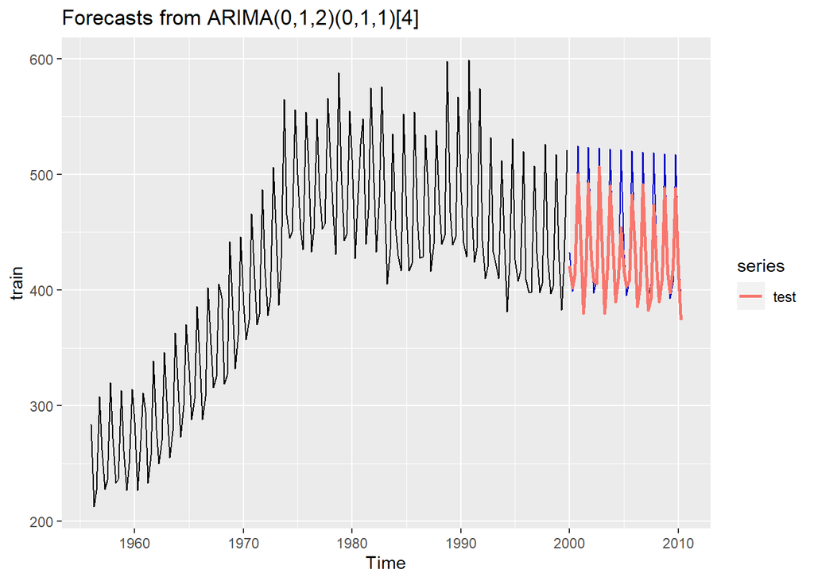

```r
autoplot(forecast(model1,h = 42),PI=F)+
  autolayer(test,size=1)
```

```r
model1_forecast = forecast(model1,h=42)
accuracy(f = model1_forecast,x = ausbeer)
```

```
##                       ME     RMSE      MAE         MPE     MAPE      MASE
## Training set  -0.4443474 14.79078 11.11090 -0.06714964 2.659077 0.6956951
## Test set     -10.3114618 19.88872 14.49978 -2.26976852 3.261576 0.9078855
##                      ACF1 Theil's U
## Training set -0.004102863        NA
## Test set     -0.269479034 0.3887556
```

### 0.4.2 ARIMA - Automatic Model Selection

Use auto.arima to pick the best model based on AICc. Sometimes auto.arima() does not yield an optimal solution as it uses computational shortcuts. By setting stepwise and approximation to False, we will ensure a more extensive search.

As it turns out, the automatic process picked the model we manually configured.

```r
model_auto = auto.arima(y = train,d = 1,D = 1,stepwise = F,approximation = F)
model_auto
```

```
## Series: train
## ARIMA(0,1,2)(0,1,1)[4]
##
## Coefficients:
##           ma1     ma2     sma1
##       -0.9758  0.3959  -0.7659
## s.e.   0.0722  0.0762   0.0520
##
## sigma^2 = 244.5:  log likelihood = -713.37
## AIC=1434.74   AICc=1434.98   BIC=1447.3
```

#### 0.4.2.1 Comparing Forecasting Models

Let us compare all the models in terms of accuracy metrics on the test sample.

```r
rbind(average_model = accuracy(f = average_model,x = ausbeer)[2,],
      naive_model = accuracy(f = naive_model,x = ausbeer)[2,],
      seasonal_naive_model = accuracy(f = seasonal_naive_model,x = ausbeer)[2,],
      drift_model = accuracy(f = drift_model,x = ausbeer)[2,],
      ses_model = accuracy(f = ses_model,x = ausbeer)[2,],
      holt_model = accuracy(f = holt_model,x = ausbeer)[2,],
      holt_damped_model = accuracy(f = holt_damped_model,x = ausbeer)[2,],
      hw_additive_model = accuracy(f = hw_additive,x = ausbeer)[2,],
      hw_multiplicative = accuracy(f = hw_multiplicative,x = ausbeer)[2,],
      ets_aaa = accuracy(ets_aaa_forecast,x = ausbeer)[2,],
      ets_auto = accuracy(ets_auto_forecast,x = ausbeer)[2,],
      arima = accuracy(model1_forecast,x=ausbeer)[2,]
      )
```

```
##                              ME      RMSE       MAE        MPE      MAPE
## average_model          15.25866  40.10097  28.70346   2.876448  6.348359
## naive_model           -93.30952 100.40881  93.30952 -22.690269 22.690269
## seasonal_naive_model  -11.54762  21.85286  17.02381  -2.521773  3.863916
## drift_model          -122.42667 129.44954 122.42667 -29.581531 29.581531
## ses_model             -18.09737  41.26471  37.68469  -4.978561  8.973630
## holt_model           -104.37559 124.04137 108.00085 -25.405766 26.131936
## holt_damped_model     -32.18055  49.84832  44.97675  -8.303939 10.897279
## hw_additive_model     -14.05834  22.67754  16.71429  -3.151230  3.775641
## hw_multiplicative     -16.47439  24.38794  18.20496  -3.721500  4.125710
## ets_aaa               -20.38991  28.22830  22.12902  -4.654819  5.060769
## ets_auto              -20.48601  28.61288  22.23155  -4.669352  5.076505
## arima                 -10.31146  19.88872  14.49978  -2.269769  3.261576
##                           MASE         ACF1 Theil's U
## average_model        1.7972318 -0.052981076 0.7832398
## naive_model          5.8424602 -0.052981076 1.8984090
## seasonal_naive_model 1.0659247  0.029098002 0.4278746
## drift_model          7.6655940  0.152038516 2.4589272
## ses_model            2.3595800 -0.052981076 0.7972014
## holt_model           6.7623392  0.611282124 2.3753720
## holt_damped_model    2.8161636 -0.005103579 0.9593471
## hw_additive_model    1.0465444 -0.185710461 0.4430322
## hw_multiplicative    1.1398809 -0.169487536 0.4757030
## ets_aaa              1.3855813  0.015455576 0.5492527
## ets_auto             1.3920011  0.010216303 0.5569420
## arima                0.9078855 -0.269479034 0.3887556
```

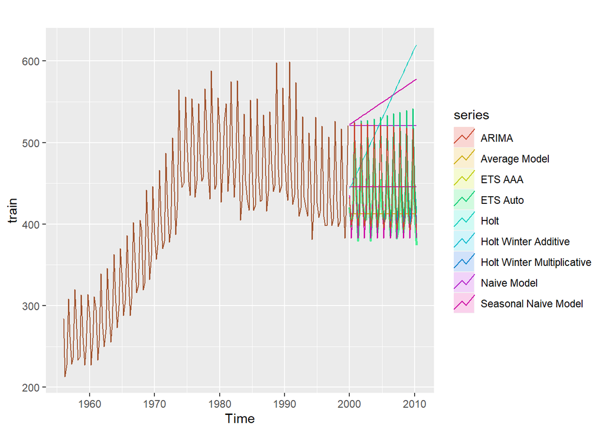

```r
autoplot(train, color='sienna')+
  autolayer(test,size=1.05,color='seagreen2')+
  autolayer(average_model,series = 'Average Model',PI=F)+
  autolayer(naive_model,series = 'Naive Model',PI=F)+
  autolayer(seasonal_naive_model,series = 'Seasonal Naive Model',PI=F)+
  autolayer(drift_model,series = 'Seasonal Naive Model',PI=F)+
  autolayer(ses_model,series = 'Seasonal Naive Model',PI=F)+
  autolayer(holt_model,series = 'Holt',PI=F)+
  autolayer(hw_additive,series = 'Holt Winter Additive',PI=F)+
  autolayer(hw_multiplicative,series = 'Holt Winter Multiplicative',PI=F)+
  autolayer(ets_aaa_forecast,series = 'ETS AAA',PI=F)+
  autolayer(ets_auto_forecast,series = 'ETS Auto',PI=F)+
  autolayer(model1_forecast,series = 'ARIMA',PI=F)
```